# CSCI 416-01/516-01: Fundamentals of AI/ML

## The precision/recall trade-off

It's not always easy to achieve high precision and high recall at the same time.

In fact, increasing precision reduces recall, and increasing recall reduces precision.

To understand this, let's consider logistic regression as implemented in scikit-learn.

In binary classification, logistic regression builds a score $S(x)$ that instance $x$ belongs to one class (let's call it $\oplus$). If $S(x)$ exceeds some threshold, the model says that $x$ is an $\oplus$; otherwise, it says $x$ is an $\ominus$.

Scikit-Learn won't let us see the threshold, but it will tell us the values of the score $S(x)$ it is using. We can get at them using the `decision_function()` method.

```python
gs.fit(X_train, y_train)

y_pred = gs.predict(X_train)
y_scores = gs.decision_function(X_train)
print('    score        class prediction')
print(np.column_stack((y_scores, y_pred)))
```

```
    score        class prediction
[[-2.87101346  0.        ]
 [-2.9973241   0.        ]
 [-0.99998987  0.        ]
 [-2.44790928  0.        ]
 [-1.4339487   0.        ]
 [ 0.65346251  1.        ]
 [-1.32056474  0.        ]
 [-2.61523693  0.        ]
 [-1.72503464  0.        ]
 [-1.16695312  0.        ]
 [-1.33264451  0.        ]
 [-3.47020525  0.        ]
 [ 1.48772483  1.        ]
 [ 3.04590067  1.        ]
 [ 1.09624853  1.        ]
 [ 0.19337034  1.        ]
 [-1.11188052  0.        ]
 [ 1.70510756  1.        ]
 [-2.81430972  0.        ]
 [ 5.6897123   1.        ]
 [-2.08858217  0.        ]
 [-2.64425556  0.        ]
 [-4.3265821   0.        ]
 [-2.91329435  0.        ]
 [ 1.30809936  1.        ]
 [-0.58837831  0.        ]
 [-3.90853656  0.        ]
 [ 5.47980698  1.        ]
 [-3.90716969  0.        ]
 [-2.23102126  0.        ]
 [-3.2016481   0.        ]
 [ 6.37585411  1.        ]
 [-2.41711246  0.        ]
 [ 6.40981802  1.        ]
 [ 5.5520393   1.        ]
 [-3.76369213  0.        ]
 [-2.71566446  0.        ]
 [-0.875811    0.        ]
 [ 1.20393034  1.        ]
```

[output cut: 344 more lines]

```
 [-3.02120327  0.        ]
 [ 0.23297687  1.        ]
 [ 2.76750132  1.        ]
 [ 5.15825729  1.        ]
 [-1.71876106  0.        ]
 [ 1.13529997  1.        ]
 [ 2.52648001  1.        ]
 [-0.72280004  0.        ]
 [ 3.46572039  1.        ]
 [-2.48377372  0.        ]
 [-6.79259423  0.        ]
 [-1.0001501   0.        ]
 [-3.65237952  0.        ]
 [ 1.25417076  1.        ]
 [-1.98696487  0.        ]]
```

We see that negative scores are Class 0 (benign) and positive scores are Class 1 (malignant).

### Precision and recall vs scoring threshold

Let's look at the effect of changing the scoring threshold on precision and recall.

We use the [`precision_recall_curve()`](http://scikit-learn.org/stable/modules/generated/sklearn.metrics.precision_recall_curve.html) function to create a plot of the precision and recall for different values of the threshold used by in our classifier to decide whether cells are malignant or benign.

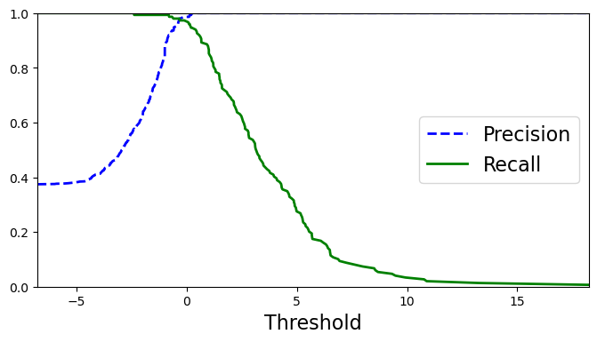

```python
from sklearn.metrics import precision_recall_curve

precisions, recalls, thresholds = precision_recall_curve(y_train, y_scores)

def plot_precision_recall_vs_threshold(precisions, recalls, thresholds):
    plt.plot(thresholds, precisions[:-1], "b--", label="Precision", linewidth=2)
    plt.plot(thresholds, recalls[:-1], "g-", label="Recall", linewidth=2)
    plt.xlabel("Threshold", fontsize=16)
    plt.legend(loc="right", fontsize=16)
    plt.ylim([0, 1])

plt.figure(figsize=(8, 4))
plot_precision_recall_vs_threshold(precisions, recalls, thresholds)
plt.xlim([np.amin(thresholds), np.amax(thresholds)])
plt.show()
```

Recall:

- **Precision**: of all the $\oplus$'s you found, how many of them were really $\oplus$'s? Good precision means that the cases we diagnose as cancer really are cancer.
- **Recall**: of all the $\oplus$'s that are really there, how many of them did you find? Good recall means that we are not missing cases of cancer.

We can see that as we increase the decision threshold in our classifier, the precision increases because we are making the requirement to be classified as $\oplus$ more stringent.

At the same time, recall is decreasing because we are missing more and more $\oplus$ cases.

Thus, if someone says they want 99.9% precision in their classsifier, they should also ask about the associated level of recall! One is not meaningful without the other.

## The precision-recall curve

Now we will plot the **precision-recall** curve that shows the trade-off between precision and recall.

We have values \begin{align*} (\mbox{threshold}_{1}, \mbox{precision}_{1}) &\quad (\mbox{threshold}_{1}, \mbox{recall}_{1}) \\ (\mbox{threshold}_{2}, \mbox{precision}_{2}) &\quad (\mbox{threshold}_{2}, \mbox{recall}_{2}) \\ \vdots &\quad \vdots \\ (\mbox{threshold}_{r}, \mbox{precision}_{r}) &\quad (\mbox{threshold}_{r}, \mbox{recall}_{r}) \end{align*}

In the precision-recall curve we plot precision vs recall: \begin{align*} (\mbox{recall}_{1}, \mbox{precision}_{1}) \\ (\mbox{recall}_{2}, \mbox{precision}_{2}) \\ \vdots \\ (\mbox{recall}_{r}, \mbox{precision}_{r}). \end{align*}

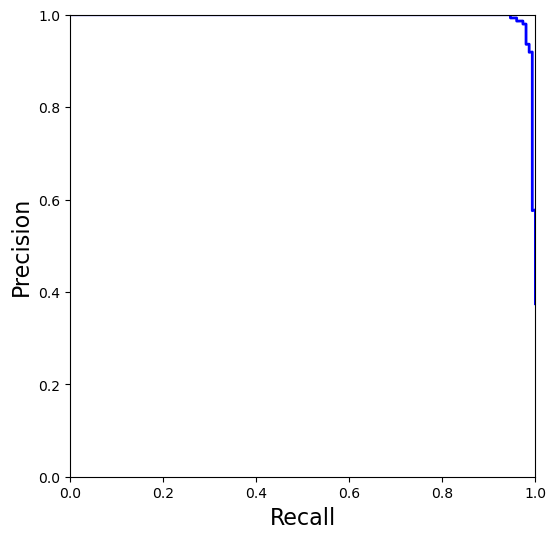

```python
def plot_precision_vs_recall(precisions, recalls):
    plt.plot(recalls, precisions, "b-", linewidth=2)
    plt.xlabel("Recall", fontsize=16)
    plt.ylabel("Precision", fontsize=16)
    plt.axis([0, 1, 0, 1])

plt.figure(figsize=(6, 6))
plot_precision_vs_recall(precisions, recalls)
plt.show()
```

This is a good precision-recall plot. As our recall improves, we do not lose much precision until the upper limit of recall is reached.

A classifier with more room for improvement would be one that does not hug the upper right corner of the enclosing square.

### A precision-recall curve for an ungood classifier

Let's look at an example where the classifier does not do well.

We will use two features of the iris data set and a logistic regression classifier.

```python
from sklearn.datasets import load_iris

iris = load_iris()

# Extract sepal length and width from columns 0 and 1.
iris_X = iris.data[:,[0,1]]
iris_y = iris.target
print(iris.target_names)

# Select I. versicolor and I. virginica.
mask = (iris_y != 0)
iris_X = iris_X[mask,:]
iris_y = iris_y[mask]
```

```
['setosa' 'versicolor' 'virginica']
```

```python
from sklearn.preprocessing import LabelEncoder
le = LabelEncoder()
iris_y = le.fit_transform(iris_y)

from sklearn.model_selection import train_test_split

iris_X_train, iris_X_test, iris_y_train, iris_y_test = \
        train_test_split(iris_X, iris_y, test_size=0.30, random_state=1)
```

```python
from sklearn.linear_model import LogisticRegression

lr = LogisticRegression(random_state=42)

lr.fit(iris_X_train, iris_y_train)
print(f"Test accuracy: {lr.score(iris_X_test, iris_y_test):.3f}")
```

```
Test accuracy: 0.700
```

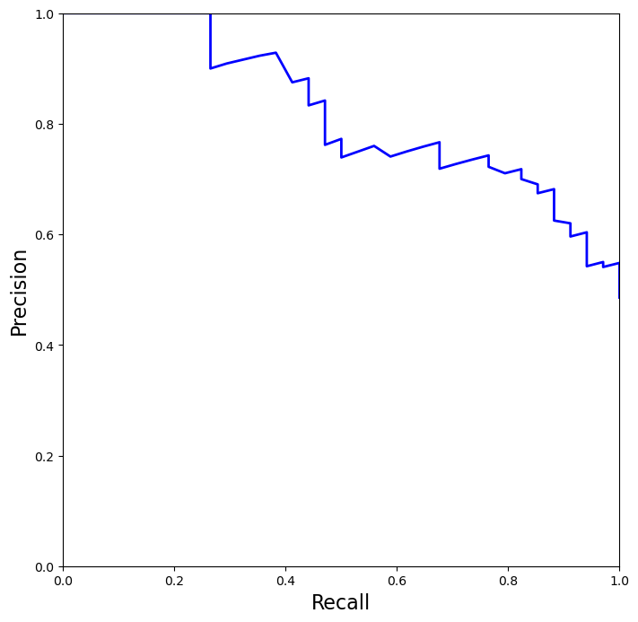

```python
from sklearn.metrics import precision_recall_curve

iris_y_scores = lr.decision_function(iris_X_train)

precisions, recalls, thresholds = precision_recall_curve(iris_y_train, iris_y_scores)

def plot_precision_vs_recall(precisions, recalls):
    plt.plot(recalls, precisions, "b-", linewidth=2)
    plt.xlabel("Recall", fontsize=16)
    plt.ylabel("Precision", fontsize=16)
    plt.axis([0, 1, 0, 1])

plt.figure(figsize=(8, 8))
plot_precision_vs_recall(precisions, recalls)
plt.show()
```

## Plotting a receiver operating characteristic curve

Another tool for evaluating binary classifiers is the **receiver operating characteristic (ROC) curve** or **normalized coverage plot**. The name comes from ROC curves in radio engineering, which were introduced in World War II to measure radio and radar performance.

Recall:

- **true positives** are correctly classified positives;
- **false positives** are incorrectly classified negatives. In true/false positive/negative,
- positive/negative refers to the classifier's prediction, while
- true/false refers to whether this prediction is correct. Let \begin{align*} P &= \mbox{true number of $\oplus$'s}, \\ N &= \mbox{true number of $\ominus$'s}, \\ TP &= \mbox{number of true positives}, \\ TN &= \mbox{number of true negatives}, \\ FP &= \mbox{number of false positives}, \\ FN &= \mbox{number of false negatives}. \end{align*}

The **true positive rate** (TPR) and **false positive rate** (FPR) are the fraction of positives correctly classified and negatives incorrectly classified, respectively: \begin{align*} TPR &= \frac{TP}{P} = \frac{TP}{FN + TP}, \\ FPR &= \frac{FP}{N} = \frac{FP}{FP + TN}. \end{align*}

An ROC curve is similar to that in the precision-recall curve. For various levels of the scoring threshold we compute the associated true positive rate (TPR) and false positive rate (FPR): \begin{align*} (\mbox{threshold}_{1}, \mbox{TPR}_{1}) &\quad (\mbox{threshold}_{1}, \mbox{FPR}_{1}) \\ (\mbox{threshold}_{2}, \mbox{TPR}_{2}) &\quad (\mbox{threshold}_{2}, \mbox{FPR}_{2}) \\ \vdots &\quad \vdots \\ (\mbox{threshold}_{r}, \mbox{TPR}_{r}) &\quad (\mbox{threshold}_{r}, \mbox{FPR}_{r}) \end{align*}

```python
from sklearn.metrics import roc_curve

fpr, tpr, thresholds = roc_curve(y_train, y_scores)
```

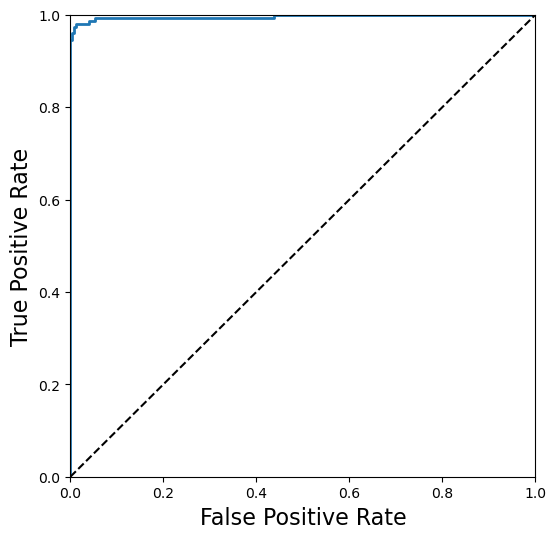

```python
def plot_roc_curve(fpr, tpr, label=None):
    plt.plot(fpr, tpr, linewidth=2, label=label)
    plt.plot([0, 1], [0, 1], 'k--')
    plt.axis([0, 1, 0, 1])
    plt.xlabel('False Positive Rate', fontsize=16)
    plt.ylabel('True Positive Rate', fontsize=16)

plt.figure(figsize=(6, 6))
plot_roc_curve(fpr, tpr)
plt.show()
```

The blue curve is the ROC curve for our classifier.

The dotted 45° line represents the performance of a random classifier. By that we mean a classifier that selects a random number $S$ from a uniform distribution on the interval [0,1], and classifies an instance as $\oplus$ if $S > \theta$, where $\theta$ is the scoring threshold.

- At one extreme, when $\theta = 0$, all instances are classified as $\oplus$. This means TPR = 1 and FPR = 1.
- At the other extreme, when $\theta = 1$, all instances are classified as $\ominus$. This means TPR = 0 and FPR = 0.
- For intermediate values of $\theta$, equal fractions of true $\oplus$ and true $\ominus$ are classified as $\oplus$, so TPR = FPR.

## The area under the ROC curve

From the perspective of the ROC curve, the ideal classifier would be the constant value 1.

- Such a classifier would always have perfect precision.
- The area under such a curve would be 1 (height = 1 $\times$ width = 1).
- The area under the random classifier's ROC is 1/2.

Th e area under an ROC curve is abbreviated AUC: **area under curve**. AUC values near 1 are desirable.

```python
from sklearn.metrics import roc_auc_score, accuracy_score

y_pred = gs.predict(X_train)

print('ROC AUC:  {0:.3f}'.format(roc_auc_score(y_train, y_scores)))
print('Accuracy: {0:.3f}'.format(accuracy_score(y_train, y_pred)))
```

[output not shown]

# The precision/recall curve vs the ROC curve

The precision/recall curve typically gives better insight when the number of $\oplus$ cases is small and you care more about false positives than false negatives.